# Métodos Numéricos Aplicados a Finanças — Turma 2025

Aula 01

Prof. Frega PPGOLD/Universidade Federal do Paraná

11/03/2025

# 1 Introdução

Aqui começamos a escrever a introdução do nosso material.

Aqui continuamos

A seguir vamos colocando outros ítens tipográficos

## 1.1 Objetivos

### 1.1.1 Objetivo Geral

### 1.1.2 Objetivo Específico

#### 1.1.2.1 Subsubseção

##### 1.1.2.1.1 Parágrafo

###### 1.1.2.1.1.1 Subparágrafo

1.1.2.1.1.1.1 Subsubparágrafo

Um subsubparágrafo é aceito pelo *markdown* mas não é definido tipograficamente. Normalmente usamos só até o nível 6, que é o subparágrafo.

# 2 Referencial teórico-empírico

# 3 Metodologia

Escrevendo uma equação

```
$$
y = ax^2+bx+c
$$
```

$$y = ax^2+bx+c$$

# 4 Análise de dados e discussão dos resultados

```r
2 + 2
```

```
## [1] 4
```

```r
set.seed(1)
.x <- rnorm(10000)
head(.x, 10)
```

```
##  [1] -0.6264538  0.1836433 -0.8356286  1.5952808  0.3295078 -0.8204684
##  [7]  0.4874291  0.7383247  0.5757814 -0.3053884
```

```r
tail(.x, 10)
```

```
##  [1]  1.04776175 -0.02428861 -0.47787499 -0.02971747  0.20966546  0.95950757
##  [7]  0.43660362  0.49936656  0.89397983  0.25738706
```

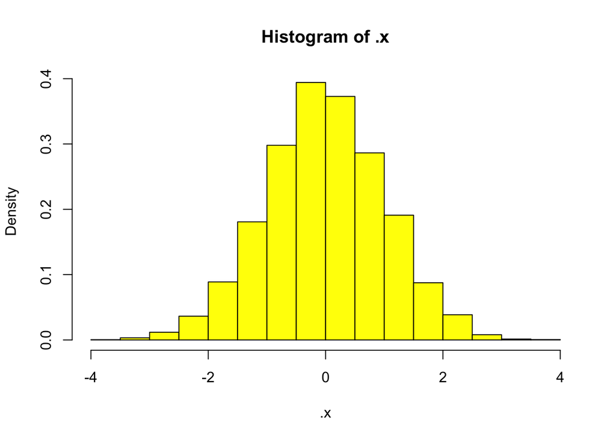

```r
hist(.x, freq = FALSE, col = "yellow", border = "black")
```

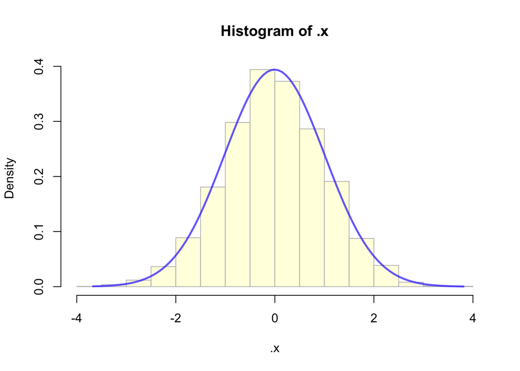

```r
hist(.x, freq = FALSE, col = "lightyellow", border = "gray")
curve(dnorm(x, mean(.x), sd(.x)), xlim = c(min(.x), max(.x)), add = TRUE, col = "#4040FFC0", lwd = 2.5)
```

```r
1 / 2
```

```
## [1] 0.5
```

# 5 Dados do Principles of Econometrics

## 5.1 Pacote `PoEdata_0.1.0.tar.gz`

Uma vez instalado o pacote PoEdata_0.1.0.tar.gz

```r
library(PoEdata)
```

```r
library(printr)
data(mroz)
head(mroz[,1:5])
```

| taxableinc | federaltax | hsiblings | hfathereduc | hmothereduc |
| --- | --- | --- | --- | --- |
| 12200 | 1494 | 1 | 14 | 16 |
| 18000 | 2615 | 8 | 7 | 3 |
| 24000 | 3957 | 4 | 7 | 10 |
| 16400 | 2279 | 6 | 7 | 12 |
| 10000 | 1063 | 3 | 7 | 7 |
| 6295 | 370 | 8 | 7 | 7 |

```r
tail(mroz[,1:5])
```

|  | taxableinc | federaltax | hsiblings | hfathereduc | hmothereduc |
| --- | --- | --- | --- | --- | --- |
| 748 | 16100 | 1825 | 0 | 7 | 12 |
| 749 | 32000 | 4701 | 8 | 12 | 7 |
| 750 | 18500 | 2720 | 4 | 12 | 12 |
| 751 | 13000 | 1642 | 6 | 7 | 12 |
| 752 | 17200 | 2447 | 2 | 7 | 10 |
| 753 | 18700 | 2327 | 4 | 10 | 7 |

## 5.2 Pequeno exemplo de programação em `R`

```r
library(DescTools)
plotSquare = function(deltay = 1.5, deltax = abs(deltay/Asp()),
                      xbase = 12, ybase = 3, col = "#FF808040") {
  polygon(c(0, deltax, deltax, 0, 0)+xbase,
          c(0, 0, deltay, deltay, 0)+ybase,
          col = col)
}

plotRegressao = function(modelo1 = modelo1, horas = horas, nota = nota, sequencia=5, sub = NULL) {
# desenho os pontos observados
plot(horas, nota, pch = 20, col = "darkgray", xlim = c(0, 14), ylim = c(0, 100), axes = FALSE, sub = "Regressão linear simples", xlab = "Horas de estudo", ylab = "Nota na avaliação", main = sub)

# desenho os eixos no (0, 0)
axis(1, pos = 0)
axis(2, pos = 0)

# traça a linha do modelo1 em azul
if(sequencia>1) abline(modelo1, col = "blue")

# calcula os pontos sobre a reta
estimados <- predict(modelo1, horas = horas)

# desenha os pontos sobre a reta
if(sequencia>2) points(horas, estimados, pch = 20, col = "blue")

# desenha as barras de erro (y - ychapéu) e dá nome aos pontos
delta = 0.3
if(sequencia>3) {
for (i in 1:length(horas)) {
  # desenha as barras de erro verticais
  lines(c(horas[i], horas[i]), c(estimados[i], nota[i]), col = "red")
  # desenha as linhas horizontais
  lines(c(horas[i]-delta, horas[i]+delta), c(estimados[i], estimados[i]), col = "red")
  lines(c(horas[i]-delta, horas[i]+delta), c(nota[i], nota[i]), col = "red")
  # coloca o nome do ponto acima ou abaixo dele conforme a estética
  text(horas[i], nota[i], bquote(y[.(i)]), pos = ifelse(estimados[i]>nota[i], 1, 3))
}
}
if(sequencia>4) {
for (i in 1:length(horas)) {
  deltay = nota[i]-estimados[i]
  deltax = abs(deltay/Asp())
  if(deltay>0) deltax = -deltax
  plotSquare(xbase = horas[i], ybase = estimados[i], deltay = deltay, deltax = deltax)
}
}

text(8, 10, expression(min(Sigma(y[i]-bar(y[i]))^2)), cex = 1.2)
text(8, 15, "Mínimos quadrados ordinários minimiza o somatório dos quadrados dos erros", cex = 0.7)
}
```

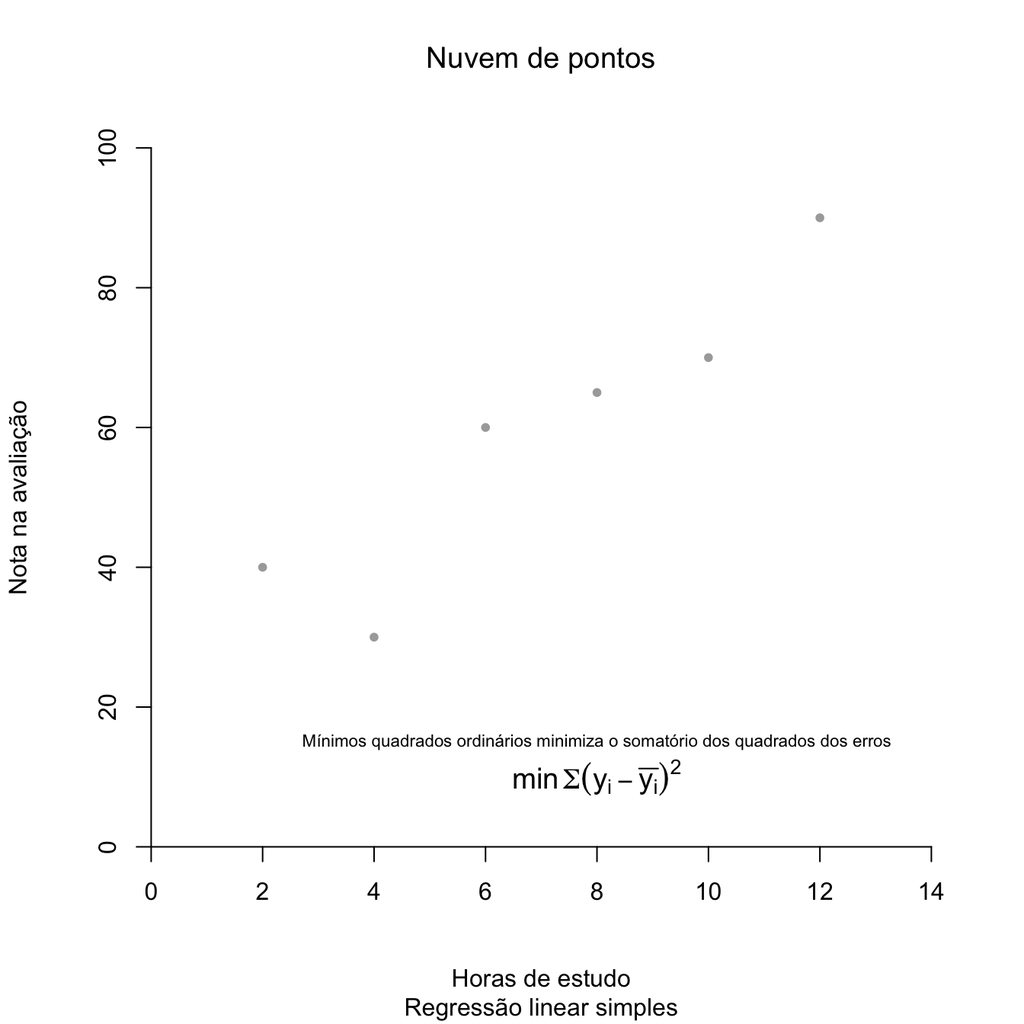

Figure 5.1: Nota na avaliação *versus* horas de estudo

```r
# conjuntos de dados
nota <- c(40, 30, 60, 65, 70, 90)
horas <- c(2, 4, 6, 8, 10, 12)
# função lm (linear model) -> guarda em modelo1
lm(nota~horas) -> modelo1


plotRegressao(modelo1, horas, nota, 1, expression("Nuvem de pontos"))
```

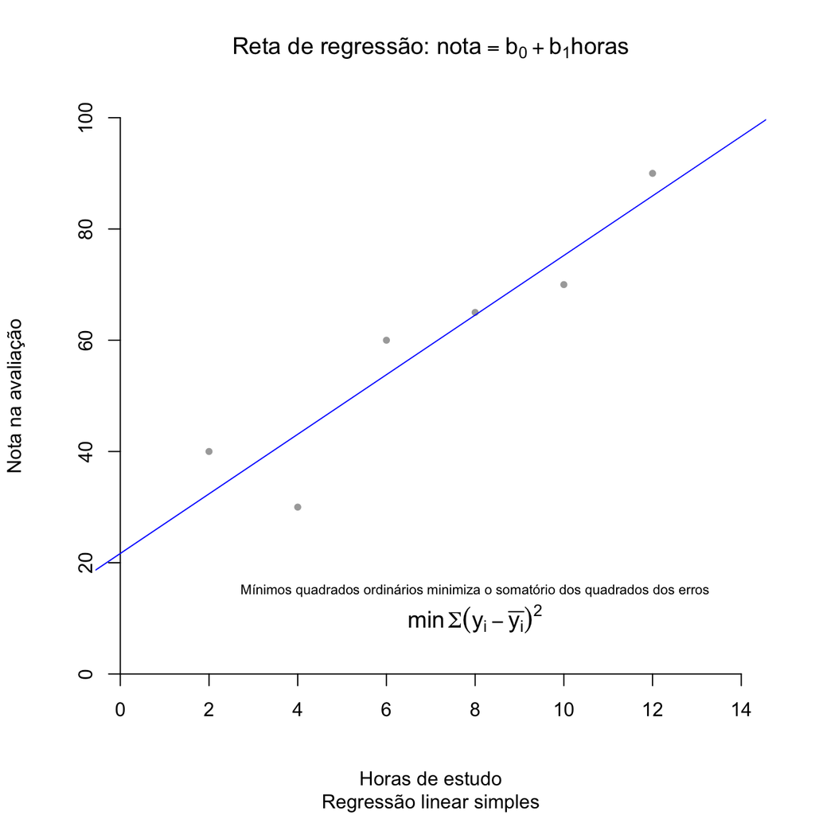

Figure 5.2: Nota na avaliação *versus* horas de estudo

```r
plotRegressao(modelo1, horas, nota, 2, expression(paste("Reta de regressão: ", nota==b[0]+b[1]*horas)))
```

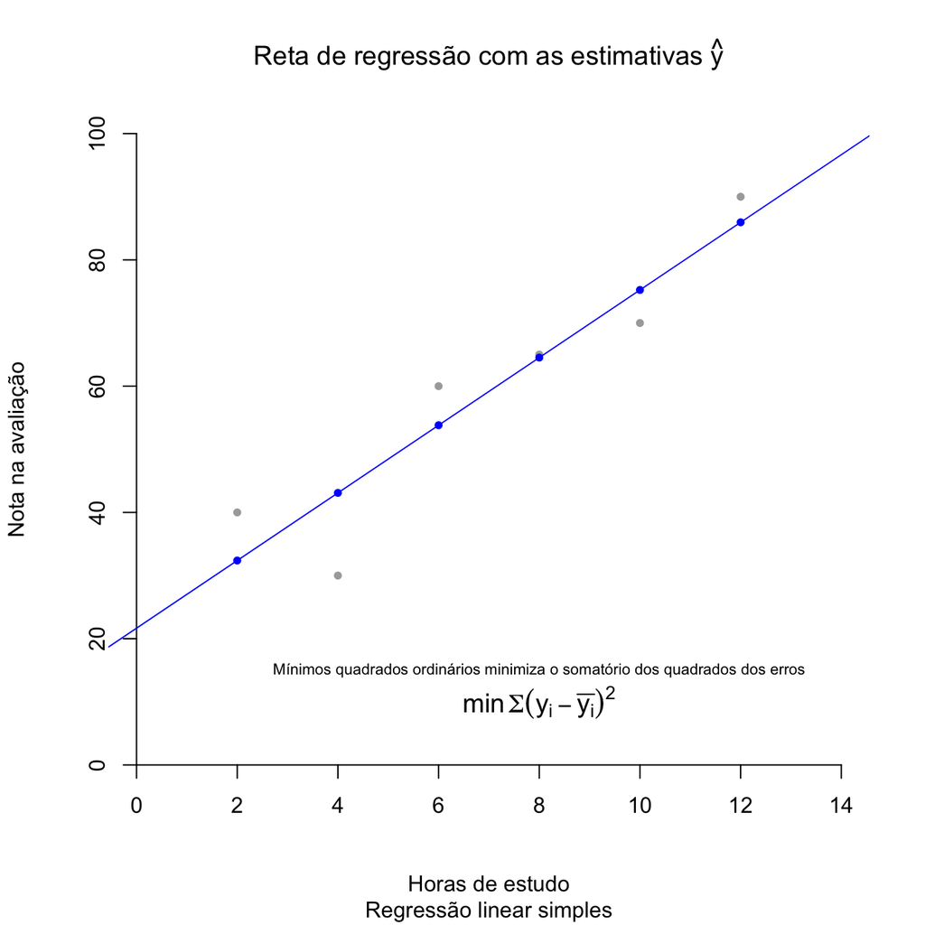

Figure 5.3: Nota na avaliação *versus* horas de estudo

```r
plotRegressao(modelo1, horas, nota, 3, expression(paste("Reta de regressão com as estimativas ", hat(y))))
```

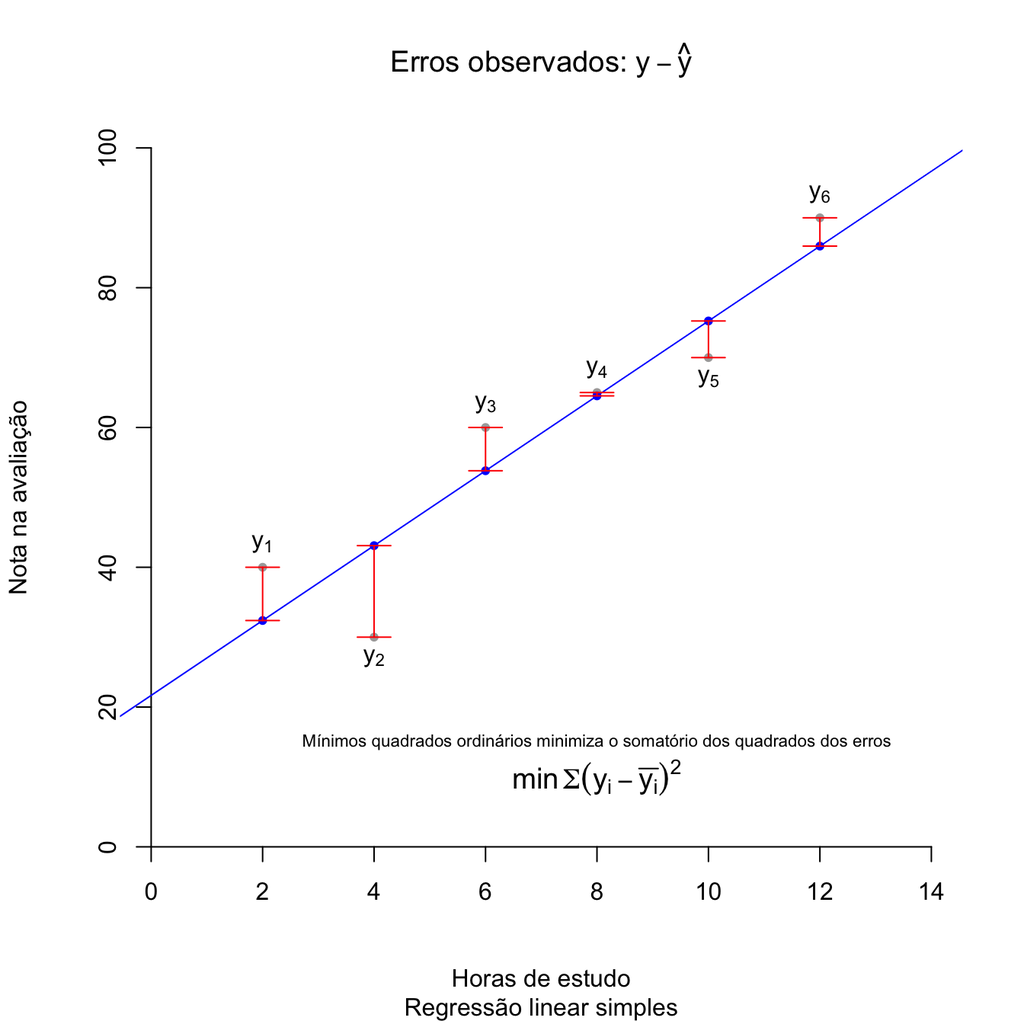

Figure 5.4: Nota na avaliação *versus* horas de estudo

```r
plotRegressao(modelo1, horas, nota, 4, expression(paste("Erros observados: ", y-hat(y))))
```

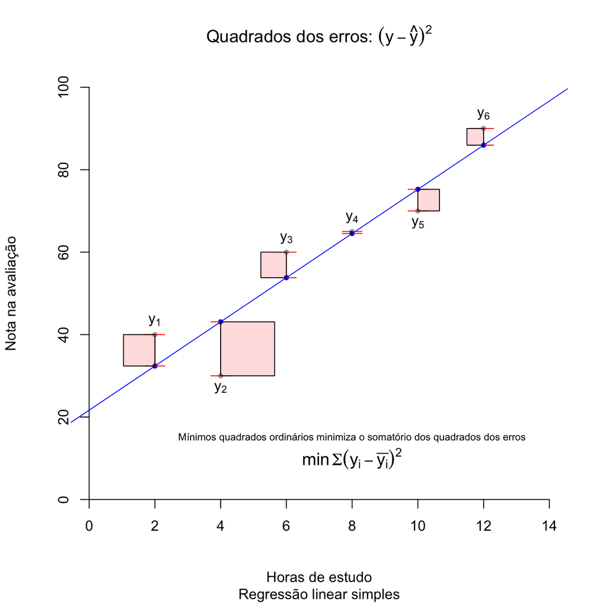

Figure 5.5: Nota na avaliação *versus* horas de estudo

```r
plotRegressao(modelo1, horas, nota, 5, expression(paste("Quadrados dos erros: ", (y-hat(y))^2)))
```

```r
modelo1
```

```
##
## Call:
## lm(formula = nota ~ horas)
##
## Coefficients:
## (Intercept)        horas
##      21.667        5.357
```

```r
modelo1$coefficients[1]
```

```
## (Intercept)
##    21.66667
```

```r
modelo1$coefficients[2]
```

```
##    horas
## 5.357143
```

```
$$
\widehat{\text{nota}} = b_0+b_1\cdot \text{horas} = 21.6666667+5.3571429\cdot \text{horas}
$$
```

$$\widehat{\text{nota}} = b_0+b_1\cdot \text{horas} = 21.6666667+5.3571429\cdot \text{horas}$$

Diagnósticos do modelo

Estatística = testes de hipóteses

Uma hipótese pode ser rejeitada ou não

Existe um valor calculado para cada teste que se chama p.value (p-valor) para o qual existe um valor crítico, normalmente tomado como 0,05 (ou 5%) que chamamos de significância do teste.

Todo teste tem uma hipótese nula ($H_0$), se o p-valor for menor que o limite, rejeita-se $H_0$, se for igual ou maior, aceita-se $H_0$.

$H_0$ do teste F: não há relação entre as variáveis.

$H_0$ do teste t: o coeficiente associado é igual a zero.

```r
summary(nota)
```

| Min. | 1st Qu. | Median | Mean | 3rd Qu. | Max. |
| --- | --- | --- | --- | --- | --- |
| 30 | 45 | 62.5 | 59.16667 | 68.75 | 90 |

```r
summary(horas)
```

| Min. | 1st Qu. | Median | Mean | 3rd Qu. | Max. |
| --- | --- | --- | --- | --- | --- |
| 2 | 4.5 | 7 | 7 | 9.5 | 12 |

```r
summary(.x)
```

| Min. | 1st Qu. | Median | Mean | 3rd Qu. | Max. |
| --- | --- | --- | --- | --- | --- |
| -3.6713 | -0.6733944 | -0.0159288 | -0.006537 | 0.6776605 | 3.810277 |

```r
summary(modelo1)
```

```
##
## Call:
## lm(formula = nota ~ horas)
##
## Residuals:
##        1        2        3        4        5        6
##   7.6190 -13.0952   6.1905   0.4762  -5.2381   4.0476
##
## Coefficients:
##             Estimate Std. Error t value Pr(>|t|)
## (Intercept)   21.667      8.221   2.636   0.0578 .
## horas          5.357      1.055   5.076   0.0071 **
## ---
## Signif. codes:  0 '***' 0.001 '**' 0.01 '*' 0.05 '.' 0.1 ' ' 1
##
## Residual standard error: 8.83 on 4 degrees of freedom
## Multiple R-squared:  0.8656, Adjusted R-squared:  0.832
## F-statistic: 25.76 on 1 and 4 DF,  p-value: 0.007102
```

$R^2$ é a porção de variação da nota que é explicada pelas horas.

# Manipulação de gráficos e expressões

O `RStudio` é bastante competente para lidar com elementos gráficos e com equações, tornando-o apropriado para a escrita acadêmica de textos dessa natureza.

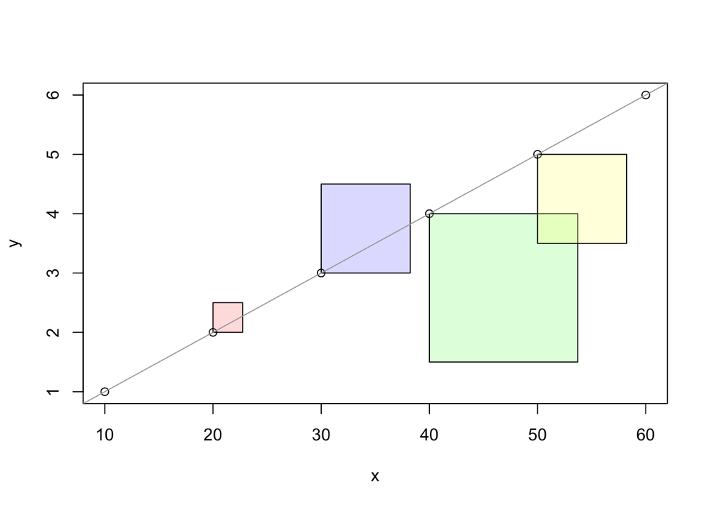

```r
x = 1:6*10
y = 1:6
plot(x, y)
plotSquare(xbase = 20, ybase = 2, deltay = 0.5)
plotSquare(xbase = 30, ybase = 3, deltay = 1.5, col = "#8080FF40")
plotSquare(xbase = 40, ybase = 4, deltay = -2.5, col = "#80FF8040")
plotSquare(xbase = 50, ybase = 5, deltay = -1.5, col = "#FFFF8040")
abline(c(0, 0.1), col = "darkgray")
```

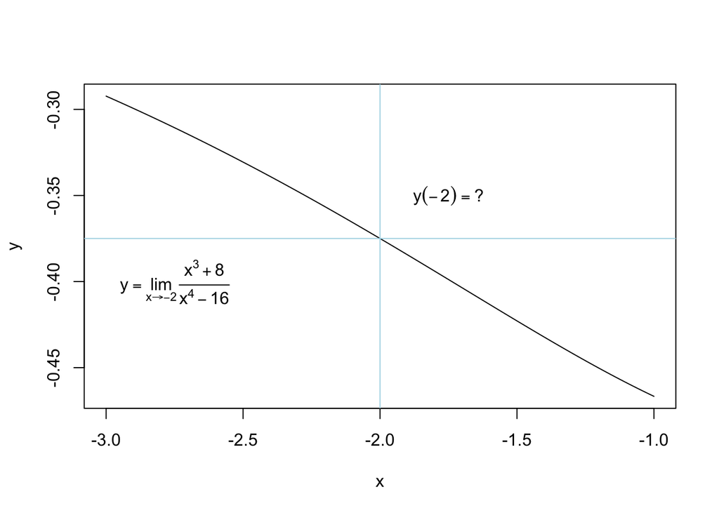

```r
f = function(x) (x^3+8)/(x^4-16)
x = seq(-3, -1.0000001, length.out = 100)
y = f(x)
plot(x, y, type = "l")
abline(v=-2, h = -3/8, col = "lightblue")
text(-2.75, -0.40, expression(y==lim(frac(x^3+8, x^4-16), x%->%-2)))
text(-1.75, -0.35, expression(y(-2)=="?"))
```

```r
f(-2.000000001)
```

```
## [1] -0.375
```

```r
-3/8
```

```
## [1] -0.375
```

Os que estudaram Cálculo talvez se lembrem da regra de L’Hôpital:

$$\lim_{x\rightarrow-2}\dfrac{x^3+8}{x^4-16}=\lim_{x\rightarrow-2}\dfrac{\rm d(x^3+8)/\rm dx}{\rm d(x^4-16)/\rm dx}= \lim_{x\rightarrow-2}\dfrac{3x^2}{4x^3} = \dfrac{3(-2)^2}{4(-2)^3} = \dfrac{12}{-32} = -\dfrac{3}{8}=-0.375$$
Mais um exemplo:

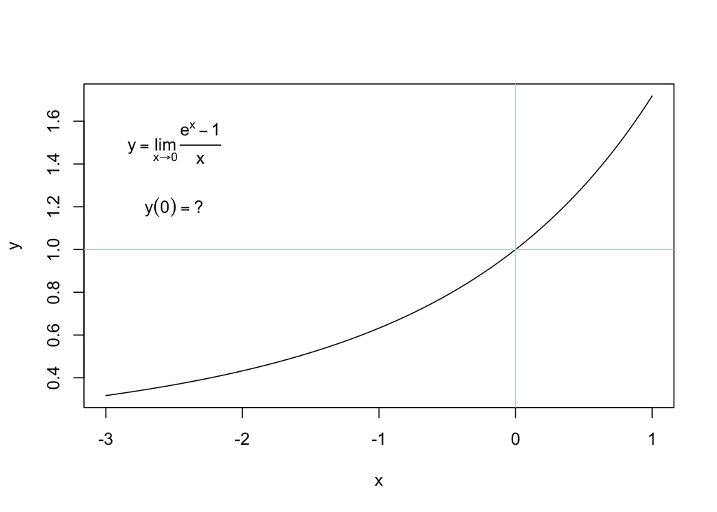

```r
f = function(x) (exp(x)-1)/(x)
x = seq(-3, 1.000000, length.out = 100)
y = f(x)
plot(x, y, type = "l")
abline(v=0, h = 1, col = "lightblue")
text(-2.5, 1.5, expression(y==lim(frac(e^x-1, x), x%->%0)))
text(-2.5, 1.2, expression(y(0)=="?"))
```

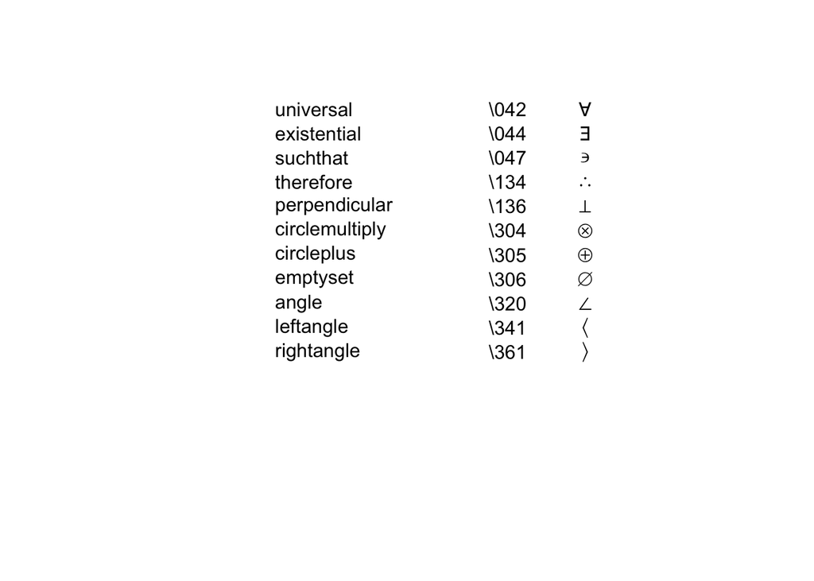

```r
plot.new(); plot.window(c(0,4), c(15,1))
text(1, 1, "universal", adj = 0); text(2.5, 1,  "\\042")
text(3, 1, expression(symbol("\042")))
text(1, 2, "existential", adj = 0); text(2.5, 2,  "\\044")
text(3, 2, expression(symbol("\044")))
text(1, 3, "suchthat", adj = 0); text(2.5, 3,  "\\047")
text(3, 3, expression(symbol("\047")))
text(1, 4, "therefore", adj = 0); text(2.5, 4,  "\\134")
text(3, 4, expression(symbol("\134")))
text(1, 5, "perpendicular", adj = 0); text(2.5, 5,  "\\136")
text(3, 5, expression(symbol("\136")))
text(1, 6, "circlemultiply", adj = 0); text(2.5, 6,  "\\304")
text(3, 6, expression(symbol("\304")))
text(1, 7, "circleplus", adj = 0); text(2.5, 7,  "\\305")
text(3, 7, expression(symbol("\305")))
text(1, 8, "emptyset", adj = 0); text(2.5, 8,  "\\306")
text(3, 8, expression(symbol("\306")))
text(1, 9, "angle", adj = 0); text(2.5, 9,  "\\320")
text(3, 9, expression(symbol("\320")))
text(1, 10, "leftangle", adj = 0); text(2.5, 10,  "\\341")
text(3, 10, expression(symbol("\341")))
text(1, 11, "rightangle", adj = 0); text(2.5, 11,  "\\361")
text(3, 11, expression(symbol("\361")))
```